# Model Comparison: Cross Validation

Last updated: 2017-03-12

## The Problem

- Models maximize the amount of variation explained in the outcome variable by the predictor variables
- Can produce results specific to the data set (i.e., overfitting)
- More complex models = more specific, less general

## Simulation

- Set up a data set where we know which variables are true predictors and which are not
- Pull outcome variable from a normal distribution
  - Two groups, differ in mean value
- Predictor 1 is the grouping variable
- All other predictors are randomly generated and unrelated to the outcome variable

## Simulation

```r
set.seed(29545)

nobs <- 10
yy <- c(rnorm(nobs / 2, 0, 1), rnorm(nobs / 2, 3, 1))
xx1 <- rep(c(0, 1), each = nobs / 2)
xx2 <- rnorm(nobs)
xx3 <- rnorm(nobs)
xx4 <- rnorm(nobs)
xx5 <- rnorm(nobs)
xx6 <- rnorm(nobs)
xx7 <- rnorm(nobs)
xx8 <- rnorm(nobs)
xx9 <- rnorm(nobs)
xx10 <- rnorm(nobs)
```

## Simulation

Fit 3 models:

```r
mod1 <- lm(yy ~ xx1)
mod2 <- lm(yy ~ xx1 + xx2 + xx3 + xx4 + xx5)
mod3 <- lm(yy ~ xx1 + xx2 + xx3 + xx4 + xx5 +
             xx6 + xx7 + xx8 + xx9 + xx10)
```

- Compare fitted values to assess how well the model fits the data
- Remember \(R^2\) = the squared correlation between the fitted and observed y values

## Model 1

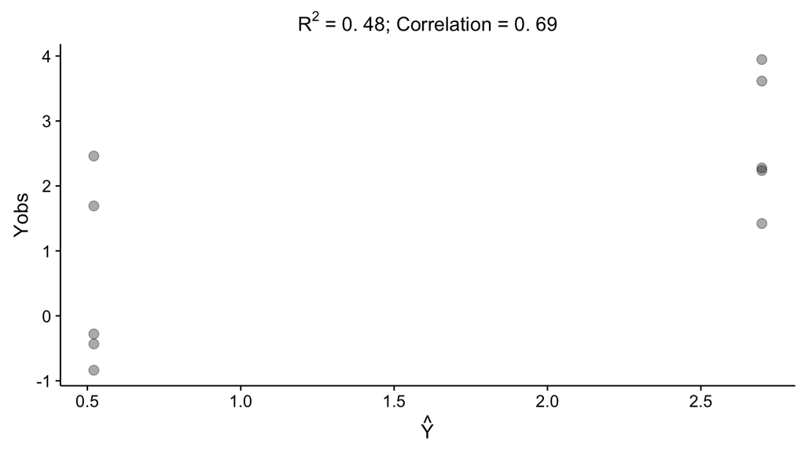

## Model 2

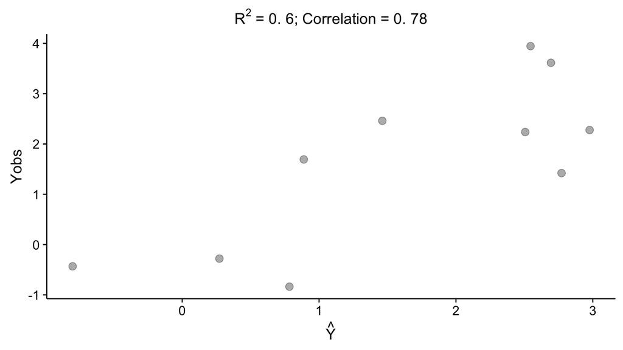

## Model 3

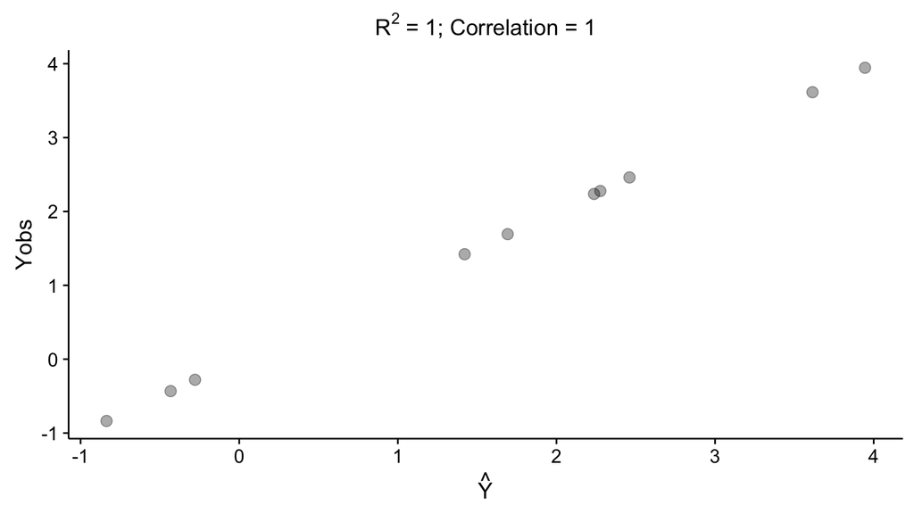

## Simulation

- How will our models perform with new data?

```r
newN <- 10
newy <- c(rnorm(newN / 2, 0, 1), rnorm(newN / 2, 3, 1))
newx <- data.frame('xx1' = rep(c(0, 1), each = newN / 2),
                   'xx2' = rnorm(newN),
                   'xx3' = rnorm(newN),
                   'xx4' = rnorm(newN),
                   'xx5' = rnorm(newN),
                   'xx6' = rnorm(newN),
                   'xx7' = rnorm(newN),
                   'xx8' = rnorm(newN),
                   'xx9' = rnorm(newN),
                   'xx10' = rnorm(newN))

y_hat_new1 <- predict.lm(object = mod1, newdata = newx)
y_hat_new2 <- predict.lm(object = mod2, newdata = newx)
y_hat_new3 <- predict.lm(object = mod3, newdata = newx)
```

## Model 1

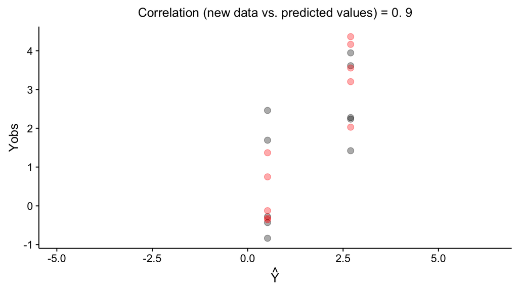

## Model 2

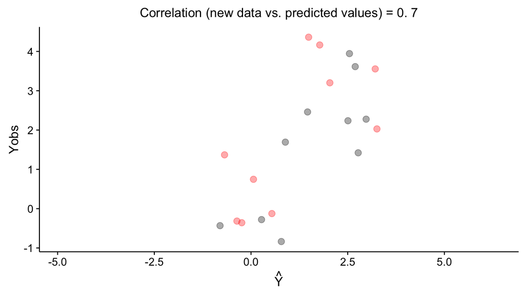

## Model 3

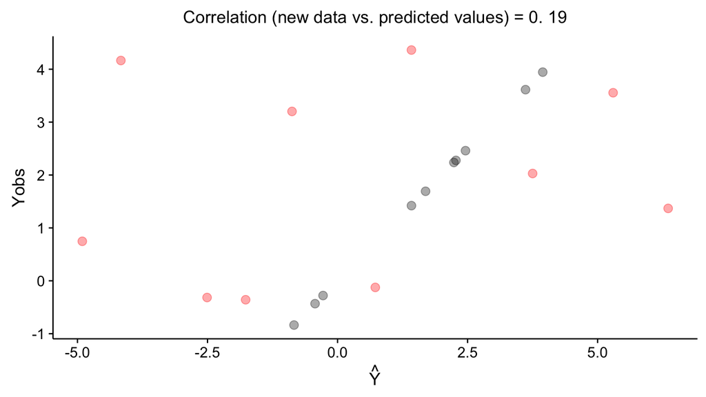

## Cross Validation

> When we don't know the true model (all cases but simulation), how do we know if a model is too specific to a given data set?
- Cross validation is one technique to address this question

## Approach

- Split data into training and test sets
- Use training set to build model
- Use test set to evaluate model
- Repeat to get average error
- **Which Predictors?**
- **What Parameter Values?**

## Approaches

- Random sub samples as test set
  - Issue: reuse of data
- K-fold cross validation
  - Issue: need large data set
- Leave one out
  - Issue: small test set

## Energy expenditure in naked mole rats

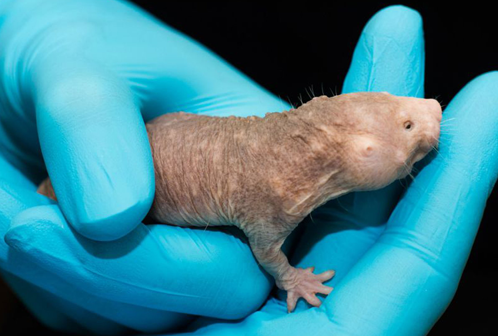

## Energy expenditure in naked mole rats

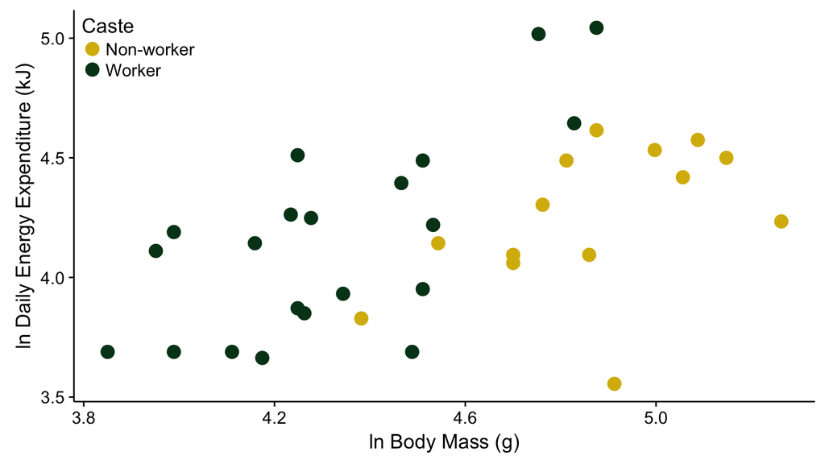

## Fit different models to these data

1. ANOVA (group mean, no body mass)
2. ANCOVA, intercepts varying
3. ANCOVA, slopes varying & intercepts varying

## Assess models with 10-fold cross validation

1. Split data into 10 ~equal sets
2. Use each set as the test set with the remaining data as the training set
3. Quantify error
   - **Mean squared error**
   - Correlation between predicted & observed values
   - Categorical outcome: % misclassified

## 10-fold cross validation

```r
set.seed(666)
folds <- 10
M$id.group <- sample(c(rep(seq(1, folds), each = 3),
                       sample(seq(1, folds), 5)))
gg <- 1:folds
err.out <- data.frame('mod1' = numeric(length = folds),
                      'mod2' = numeric(length = folds),
                      'mod3' = numeric(length = folds))
```

## 10-fold cross validation

```r
for(ii in gg) {
  M_train <- M[M$id.group != ii, ]
  mod1 <- lm(Energy ~ Caste, data = M_train)
  mod2 <- lm(Energy ~ Mass + Caste, data = M_train)
  mod3 <- lm(Energy ~ Mass * Caste, data = M_train)
  M_test <- M[M$id.group == ii, ]
  pp1 <- predict(mod1, M_test)
  pp2 <- predict(mod2, M_test)
  pp3 <- predict(mod3, M_test)
  err.out[ii, 'mod1'] <- mean((M_test$Energy - pp1) ^ 2)
  err.out[ii, 'mod2'] <- mean((M_test$Energy - pp2) ^ 2)
  err.out[ii, 'mod3'] <- mean((M_test$Energy - pp3) ^ 2)
}
```

## Visualizing MSE of one "fold"

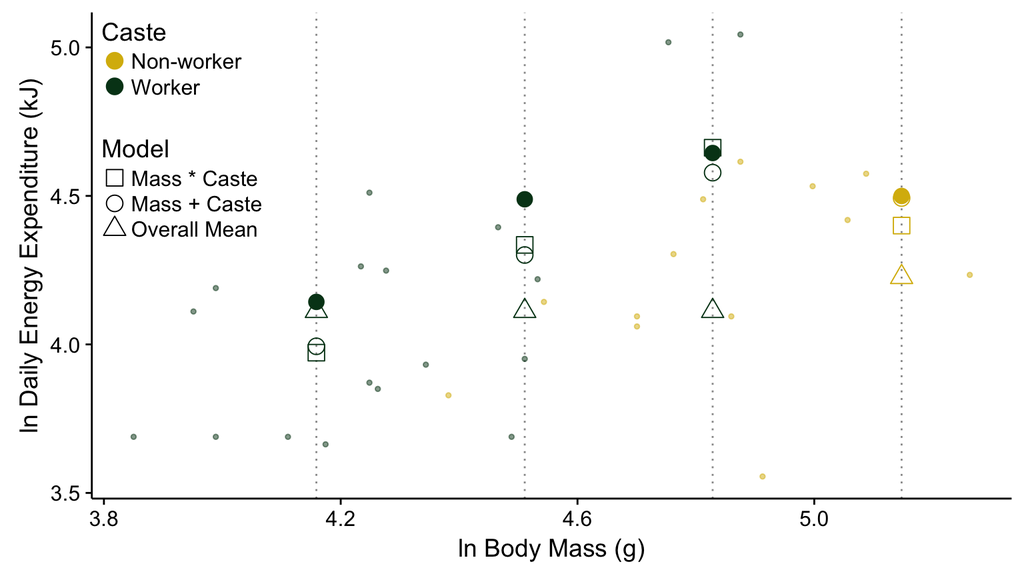

## 10-fold cross validation

```r
err.out
```

```
##          mod1       mod2       mod3
## 1  0.23011971 0.21094474 0.22709415
## 2  0.22573955 0.10945077 0.10897774
## 3  0.18777721 0.19136679 0.18244389
## 4  0.05618306 0.07876007 0.08524034
## 5  0.29977131 0.12918727 0.11271465
## 6  0.14973440 0.08386799 0.06360177
## 7  0.03073778 0.05962533 0.07348928
## 8  0.06643489 0.02635749 0.03388511
## 9  0.13409340 0.02338377 0.01833311
## 10 0.12511909 0.01549516 0.01576977
```

```r
colMeans(err.out)
```

```
##       mod1       mod2       mod3
## 0.15057104 0.09284394 0.09215498
```

## 10-fold cross validation

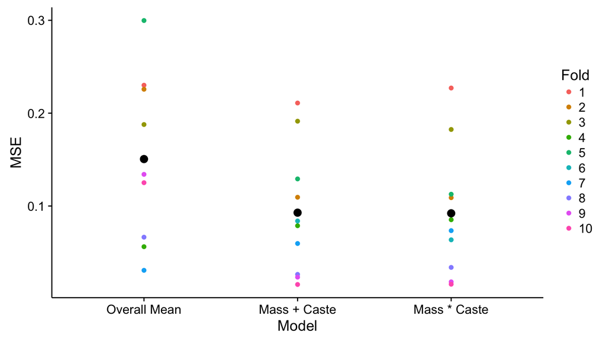

## Notes & Resources

- Training and Test sets must come from the same population
- There is uncertainty in cross validation estimates
- We've written our own code here but there are several R packages:
  - `cvTools` package
  - `boot` package

## No Quiz

No more Lectures